# Reproducible Research: Course Project 2

Jonathan Chang

February 8, 2017

## Effect of Weather Events on Population Health and the Economy in the U.S.

### Synopsis

In this document, we analyze the effect of different types of storms and other severe weather events on public health and the economy. We use the [Storm Data](https://d396qusza40orc.cloudfront.net/repdata%2Fdata%2FStormData.csv.bz2) dataset from the U.S. National Oceanic and Atmospheric Administration’s (NOAA) storm database. In the data processing step, we answer the following two questions:

1. Across the United States, which types of events (as indicated in the 𝙴𝚅𝚃𝚈𝙿𝙴 variable) are most harmful with respect to population health?
2. Across the United States, which types of events have the greatest economic consequences?

In the results section, we summarized our findings in graph form.

## Data Processing

### Initial Processing Steps

We cache this code chunk because the preprocessing steps of downloading and reading the CSV file into memory are very time-consuming.

```r
setwd("~/DSU/datasciencecoursera/reproducibleresearch/Project2")
fileUrl <- "https://d396qusza40orc.cloudfront.net/repdata%2Fdata%2FStormData.csv.bz2"
if(!file.exists("ProjectData")) {dir.create("ProjectData")}
download.file(fileUrl, destfile = "./ProjectData/StormData.csv.bz2", method = "curl")
stormdata <- read.csv("./ProjectData/StormData.csv.bz2")
```

Initial info about the storm database:

```r
dim(stormdata)
```

```
## [1] 902297     37
```

```r
names(stormdata)
```

```
##  [1] "STATE__"    "BGN_DATE"   "BGN_TIME"   "TIME_ZONE"  "COUNTY"
##  [6] "COUNTYNAME" "STATE"      "EVTYPE"     "BGN_RANGE"  "BGN_AZI"
## [11] "BGN_LOCATI" "END_DATE"   "END_TIME"   "COUNTY_END" "COUNTYENDN"
## [16] "END_RANGE"  "END_AZI"    "END_LOCATI" "LENGTH"     "WIDTH"
## [21] "F"          "MAG"        "FATALITIES" "INJURIES"   "PROPDMG"
## [26] "PROPDMGEXP" "CROPDMG"    "CROPDMGEXP" "WFO"        "STATEOFFIC"
## [31] "ZONENAMES"  "LATITUDE"   "LONGITUDE"  "LATITUDE_E" "LONGITUDE_"
## [36] "REMARKS"    "REFNUM"
```

```r
head(stormdata)
```

```
##   STATE__           BGN_DATE BGN_TIME TIME_ZONE COUNTY COUNTYNAME STATE
## 1       1  4/18/1950 0:00:00     0130       CST     97     MOBILE    AL
## 2       1  4/18/1950 0:00:00     0145       CST      3    BALDWIN    AL
## 3       1  2/20/1951 0:00:00     1600       CST     57    FAYETTE    AL
## 4       1   6/8/1951 0:00:00     0900       CST     89    MADISON    AL
## 5       1 11/15/1951 0:00:00     1500       CST     43    CULLMAN    AL
## 6       1 11/15/1951 0:00:00     2000       CST     77 LAUDERDALE    AL
##    EVTYPE BGN_RANGE BGN_AZI BGN_LOCATI END_DATE END_TIME COUNTY_END
## 1 TORNADO         0                                               0
## 2 TORNADO         0                                               0
## 3 TORNADO         0                                               0
## 4 TORNADO         0                                               0
## 5 TORNADO         0                                               0
## 6 TORNADO         0                                               0
##   COUNTYENDN END_RANGE END_AZI END_LOCATI LENGTH WIDTH F MAG FATALITIES
```

[output cut: 20 more lines]

### 1. Across the United States, which types of events (as indicated in the 𝙴𝚅𝚃𝚈𝙿𝙴 variable) are most harmful with respect to population health?

Looking at the available, columns of data, it seems that the two variables related to population health that we can use to address this question are **FATALITIES** and **INJURIES**. First, we aggregate the total fatalities and injuries with respect to the **EVTYPE** variable.

```r
fatalities <- aggregate(FATALITIES ~ EVTYPE, stormdata, sum)
injuries <- aggregate(INJURIES ~ EVTYPE, stormdata, sum)
```

We see that there are *985* types of events by doing a count **EVTYPE** levels.

```r
nlevels(stormdata$EVTYPE)
```

```
## [1] 985
```

We order the list, narrow it down to the 10 events that are most harmful to population health by causing the most fatalities and injuries respectively, and then factor the fatalities and injuries by **EVTYPE**.

```r
top_10_fatalities <- fatalities[order(fatalities$FATALITIES, decreasing=TRUE), ][1:10, ]
top_10_fatalities$EVTYPE <- factor(top_10_fatalities$EVTYPE, levels = top_10_fatalities$EVTYPE)
print(top_10_fatalities)
```

```
##             EVTYPE FATALITIES
## 834        TORNADO       5633
## 130 EXCESSIVE HEAT       1903
## 153    FLASH FLOOD        978
## 275           HEAT        937
## 464      LIGHTNING        816
## 856      TSTM WIND        504
## 170          FLOOD        470
## 585    RIP CURRENT        368
## 359      HIGH WIND        248
## 19       AVALANCHE        224
```

```r
top_10_injuries <- injuries[order(injuries$INJURIES, decreasing=TRUE), ][1:10, ]
top_10_injuries$EVTYPE <- factor(top_10_injuries$EVTYPE, levels = top_10_injuries$EVTYPE)
print(top_10_injuries)
```

```
##                EVTYPE INJURIES
## 834           TORNADO    91346
## 856         TSTM WIND     6957
## 170             FLOOD     6789
## 130    EXCESSIVE HEAT     6525
## 464         LIGHTNING     5230
## 275              HEAT     2100
## 427         ICE STORM     1975
## 153       FLASH FLOOD     1777
## 760 THUNDERSTORM WIND     1488
## 244              HAIL     1361
```

### 2. Across the United States, which types of events have the greatest economic consequences?

Examining the available data, there are four variables related to economic consequences that are of interest to us: * **PROPDMG** * **CROPDMG** * **PROPDMGEXP** * **CROPDMGEXP** **PROPDMG** and **CROPDMG** refer to property damage and crop damage respectively, and **PROPDMGEXP** and **CROPDMGEXP** are used to signify magnitude. Let us first take a look at the magnitude levels.

```r
levels(stormdata$PROPDMGEXP)
```

```
##  [1] ""  "-" "?" "+" "0" "1" "2" "3" "4" "5" "6" "7" "8" "B" "h" "H" "K"
## [18] "m" "M"
```

```r
levels(stormdata$CROPDMGEXP)
```

```
## [1] ""  "?" "0" "2" "B" "k" "K" "m" "M"
```

Then, we find the total property and crop damage values by mapping the exponent symbols to their correct magnitudes, and then multiplying by the **PROPDMG** and **CROPDMG** values. We assume that *H* = 1e2, *K* = 1e3, *M* = 1e6, *B* = 1e9, and numerical values represent exponents. All other values, we assumed were invalid, so we assigned 0’s to them. We create two new columns called **total_propdmg** and **total_cropdmg**, and a column called **total_econdmg** that is the sum of the property and crop damages.

```r
library(plyr)
propdmg_magnitude <- mapvalues(stormdata$PROPDMGEXP,
    c("", "-", "?", "+", "0", "1", "2", "3", "4", "5", "6", "7", "8", "B", "h", "H", "K", "m", "M"),
    c(0,   0,   0,   0,   1,  1e1, 1e2, 1e3, 1e4, 1e5, 1e6, 1e7, 1e8, 1e9, 1e2, 1e2, 1e3, 1e6, 1e6))

cropdmg_magnitude <- mapvalues(stormdata$CROPDMGEXP,
    c("",  "?", "0", "2", "B", "k", "K", "m", "M"),
    c(0,    0,   1,  1e2, 1e9, 1e3, 1e3, 1e6, 1e6))

stormdata$total_propdmg <- stormdata$PROPDMG * as.numeric(propdmg_magnitude)
stormdata$total_cropdmg <- stormdata$CROPDMG * as.numeric(cropdmg_magnitude)
stormdata$total_econdmg <- stormdata$total_cropdmg + stormdata$total_propdmg
```

Now, we can perform similar analysis to question 1, aggregating the sum of the property and crop damages with respect to **EVTYPE**, and then finding the top 10 events that cause the most damage. It makes more sense to combine the property and crop damage values in this question because dollars are quantifiable whereas it is difficult to determine the value of population health. For example how many injuries equates to one fatality?

```r
totaldmg <- aggregate(total_econdmg ~ EVTYPE, stormdata, sum)
top_10_totaldmg <- totaldmg[order(totaldmg$total_econdmg, decreasing=TRUE), ][1:10, ]
top_10_totaldmg$EVTYPE <- factor(top_10_totaldmg$EVTYPE, levels = top_10_totaldmg$EVTYPE)
print(top_10_totaldmg)
```

```
##                 EVTYPE total_econdmg
## 834            TORNADO    16706223.6
## 153        FLASH FLOOD     8037778.0
## 856          TSTM WIND     7235577.8
## 244               HAIL     6382727.3
## 170              FLOOD     5409925.8
## 760  THUNDERSTORM WIND     4725943.6
## 464          LIGHTNING     3035230.8
## 786 THUNDERSTORM WINDS     2310765.1
## 359          HIGH WIND     1721510.6
## 972       WINTER STORM      678221.9
```

## Results

Now, we can plot our results and visualize the answers for both questions:

##### 1. Across the United States, which types of events (as indicated in the 𝙴𝚅𝚃𝚈𝙿𝙴 variable) are most harmful with respect to population health?

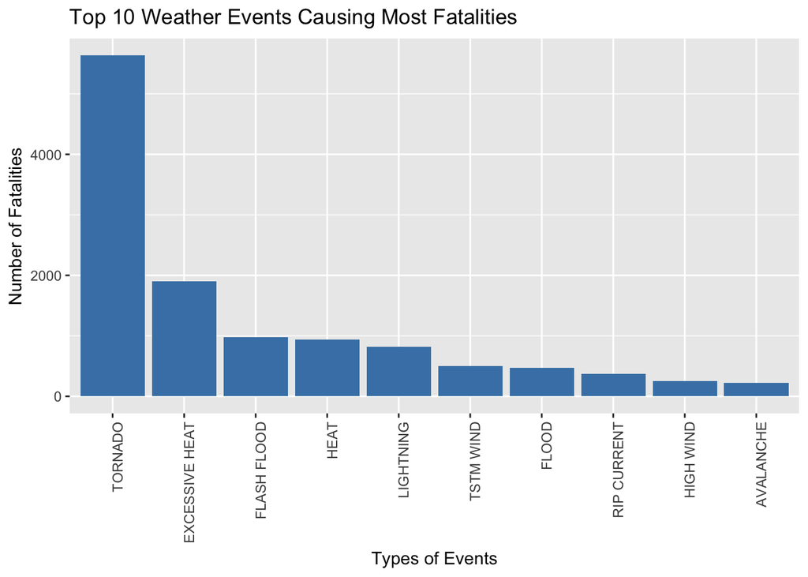

```r
library(ggplot2)
ggplot(data=top_10_fatalities, aes(x=EVTYPE, y=FATALITIES, fill=EVTYPE)) +
        geom_bar(stat="identity", fill="steelblue") +
        guides(fill=FALSE) +
        theme(axis.text.x = element_text(angle = 90, hjust = 1)) +
        xlab("Types of Events") + ylab("Number of Fatalities") +
        ggtitle("Top 10 Weather Events Causing Most Fatalities")
```

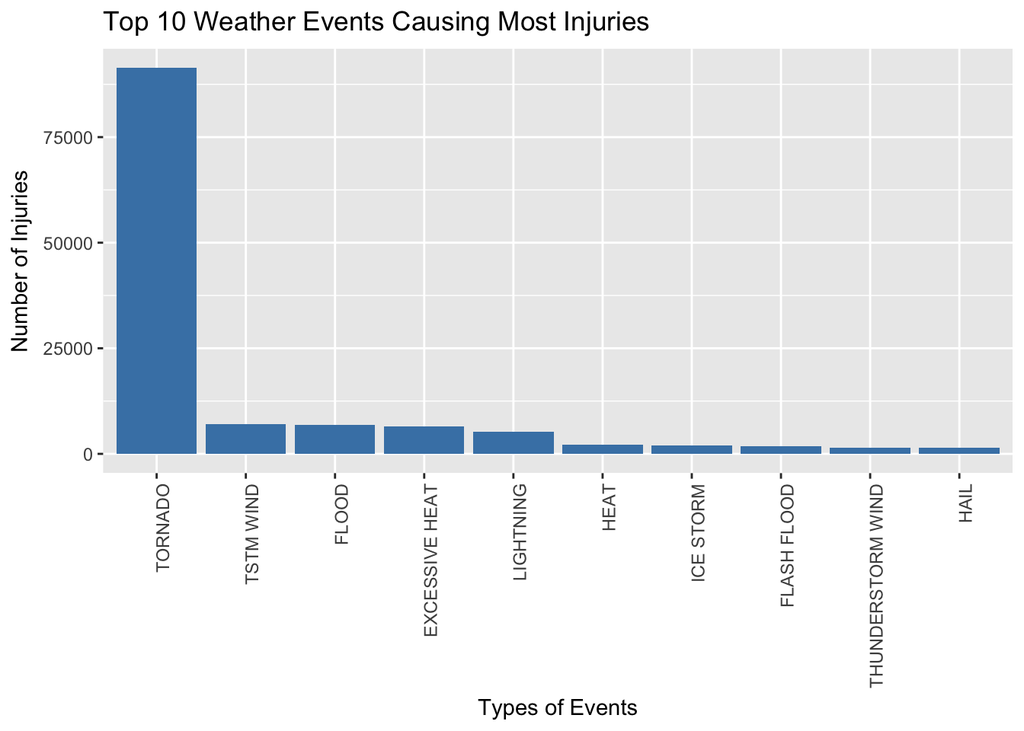

```r
ggplot(data=top_10_injuries, aes(x=EVTYPE, y=INJURIES, fill=EVTYPE)) +
        geom_bar(stat="identity", fill="steelblue") +
        guides(fill=FALSE) +
        theme(axis.text.x = element_text(angle = 90, hjust = 1)) +
        xlab("Types of Events") + ylab("Number of Injuries") +
        ggtitle("Top 10 Weather Events Causing Most Injuries")
```

##### 2. Across the United States, which types of events have the greatest economic consequences?

Again, we aggregated the sum of the property and crop damage values because dollars are quantifiable compared to fatalities and injuries.

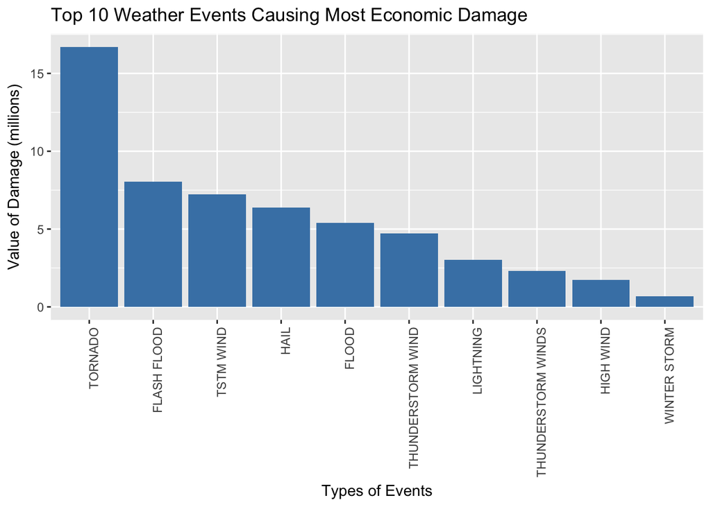

```r
ggplot(data=top_10_totaldmg, aes(x=EVTYPE, y=total_econdmg/1e6, fill=EVTYPE)) +
        geom_bar(stat="identity", fill="steelblue") +
        guides(fill=FALSE) +
        theme(axis.text.x = element_text(angle = 90, hjust = 1)) +
        xlab("Types of Events") + ylab("Value of Damage (millions)") +
        ggtitle("Top 10 Weather Events Causing Most Economic Damage")
```